# GSE 524 Lab 9

## Instructions

You will submit an HTML document to Canvas as your final version.

Your document should show your code chunks/cells as well as any output. Make sure that only relevant output is printed. Do not, for example, print the entire dataset in your final knitted file.

Your document should also be clearly organized, so that it is easy for a reader to find your answers to each question.

Libraries needed for this lab:

```r
library(tidyverse)
library(tidymodels)
```

```r
library(rpart.plot)
library(discrim)
library(baguette)
library(janitor)
library(ggplot2)
library(ggcorrplot)
library(keras)
library(vip)
```

## Dataset 1: Mushrooms

The first dataset we will study today concerns mushrooms that grow in the wild. An expert mushroom forager can identify the species by its appearance, and determine if the mushroom is edible or poisonous.

Can we train a model to do the same?

Read the data in as follows. (You do need the extra bit of code in the read_csv function, make sure you copy it over.)

```r
mushrooms <- read_csv("https://www.dropbox.com/s/jk5q3dq1u63ey1e/mushrooms.csv?dl=1",
                      col_types = str_c(rep("c", 23), collapse = ""))
```

You can find further documentation of the dataset here: https://www.kaggle.com/uciml/mushroom-classification

### Part One: A perfect tree

```r
mushrooms <- mushrooms %>%
  mutate_if(sapply(mushrooms, is.character), as.factor) %>%
  janitor::clean_names() %>%
  dplyr::select(-veil_type)
```

Fit a single decision tree to the full mushroom data, and plot the resulting tree.

```r
mushrooms_recipe <- recipe(class ~ .,
                     data = mushrooms)

tree_mod <- decision_tree() %>%
  set_engine("rpart") %>%
  set_mode("classification")

tree_wflow <- workflow() %>%
  add_recipe(mushrooms_recipe) %>%
  add_model(tree_mod)

tree_fit <- tree_wflow %>%
  fit(mushrooms)

tree_fitted <- tree_fit %>%
  pull_workflow_fit()
```

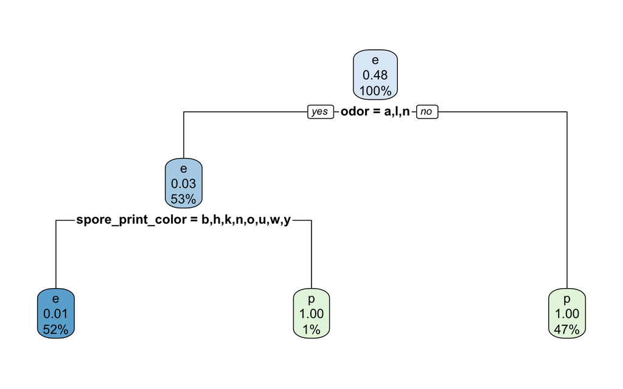

```r
rpart.plot(tree_fitted$fit)
```

You should find that almost all mushrooms are perfectly classified; that is, the resulting leaf nodes are very close to 100% pure.

Based on the tree that results, suggest a “nature guide” that tells people which mushrooms are safe to eat and which aren’t.

### Part Two: … or is it?

Before we send people off into the world to each poisonous mushrooms, we want to be confident of our guidelines. The decision tree in Q1 may achieve perfection on the data it is fit to, but do we believe these guidelines will hold for future data?

Apply each of the following resampling and/or ensemble techniques to this classification problem. For each, make an argument from the results.

You should either argue that

1. The classification rules we learned in Part One probably apply to all mushrooms; or
2. The classification rules we learned in Part One are overfit to this particular sample of mushrooms and/or set off predictors.

#### Q1: Cross-validation

```r
mush_wflow <- workflow() %>%
  add_model(tree_mod) %>%
  add_recipe(mushrooms_recipe)

mush_cv <- vfold_cv(mushrooms, 5)

mush_wflow %>%
  fit_resamples(mush_cv) %>%
  collect_metrics()
```

```
## # A tibble: 2 × 6
##   .metric  .estimator  mean     n  std_err .config
##   <chr>    <chr>      <dbl> <int>    <dbl> <chr>
## 1 accuracy binary     0.994     5 0.000663 Preprocessor1_Model1
## 2 roc_auc  binary     0.994     5 0.000651 Preprocessor1_Model1
```

- After cross-validation we still have a 99% accuracy, meaning we have not overtfit out decision tree to this dataset.

#### Q2: Bagging

```r
bag_mod <- bag_tree() %>%
  set_engine("rpart", times = 10) %>%
  set_mode("classification")

mush_bag_wflow <- workflow() %>%
  add_model(bag_mod) %>%
  add_recipe(mushrooms_recipe)

mush_bag_fit <- mush_bag_wflow %>%
  fit(mushrooms)

mushrooms %>%
  mutate(
    preds = predict(mush_bag_fit, mushrooms)$.pred_class
  ) %>%
  metrics(truth = class,
          estimate = preds)
```

```
## # A tibble: 2 × 3
##   .metric  .estimator .estimate
##   <chr>    <chr>          <dbl>
## 1 accuracy binary             1
## 2 kap      binary             1
```

- After bagging we get 100% accuracy. This makes sense since if we can sort a dataset with 99% accuracy then we should be able to sort a sub sample of that dataset perfectly. This further proves that our decision tree was not over fit to mushrooms dataset.

#### Q3: Random forests

```r
mtry_grid <- grid_regular(mtry(c(1, 15)), levels = 5)

rf_mod <- rand_forest(mtry = tune()) %>%
  set_engine("ranger") %>%
  set_mode("classification")

mush_rf_wflow <- workflow() %>%
  add_model(rf_mod) %>%
  add_recipe(mushrooms_recipe)

mush_rf_fit <- mush_rf_wflow %>%
  tune_grid(
    grid = mtry_grid,
    resamples = mush_cv
    )

mush_rf_fit %>% collect_metrics()
```

```
## # A tibble: 10 × 7
##     mtry .metric  .estimator  mean     n    std_err .config
##    <int> <chr>    <chr>      <dbl> <int>      <dbl> <chr>
##  1     1 accuracy binary     0.991     5 0.00106    Preprocessor1_Model1
##  2     1 roc_auc  binary     1.00      5 0.00000680 Preprocessor1_Model1
##  3     4 accuracy binary     1         5 0          Preprocessor1_Model2
##  4     4 roc_auc  binary     1         5 0          Preprocessor1_Model2
##  5     8 accuracy binary     1         5 0          Preprocessor1_Model3
##  6     8 roc_auc  binary     1         5 0          Preprocessor1_Model3
##  7    11 accuracy binary     1         5 0          Preprocessor1_Model4
##  8    11 roc_auc  binary     1         5 0          Preprocessor1_Model4
##  9    15 accuracy binary     1         5 0          Preprocessor1_Model5
## 10    15 roc_auc  binary     1         5 0          Preprocessor1_Model5
```

- Random Forests give us perfect accuracy as long as more than one variable is used per tree. This further enhances the decision tree model since it shows that high accuracy of our initial model did not depend on any particular variable.

#### Q4: Neural networks

```r
mush_bag_fit <- mush_bag_wflow %>%
  fit(mushrooms)

mushrooms %>%
  mutate(
    preds = predict(mush_bag_fit, mushrooms)$.pred_class
  ) %>%
  metrics(truth = class,
          estimate = preds)
```

```
## # A tibble: 2 × 3
##   .metric  .estimator .estimate
##   <chr>    <chr>          <dbl>
## 1 accuracy binary             1
## 2 kap      binary             1
```

```r
mushrooms_recipe2 <- recipe(class ~ .,
                     data = mushrooms) %>%
  step_dummy(all_nominal_predictors())
```

```r
nn_mod <- mlp(
  hidden_units = tune(),
  penalty = tune(),
  epochs = 10,
  activation = "linear"
) %>%
  set_engine("keras") %>%
  set_mode("classification")

nn_wflow <- workflow() %>%
  add_recipe(mushrooms_recipe2) %>%
  add_model(nn_mod)

nn_grid <- grid_regular(
  hidden_units(c(2, 8)),
  penalty(c(-5, 0)),
  levels = 2
)

nn_grid_search <-
  tune_grid(
    nn_wflow,
    resamples = mush_cv,
    grid = nn_grid
  )

tuning_metrics <- nn_grid_search %>%
  collect_metrics()

tuning_metrics
```

```
## # A tibble: 8 × 8
##   hidden_units penalty .metric  .estimator  mean     n    std_err .config
##          <int>   <dbl> <chr>    <chr>      <dbl> <int>      <dbl> <chr>
## 1            2 0.00001 accuracy binary     0.998     5 0.000686   Preprocessor1…
## 2            2 0.00001 roc_auc  binary     1.00      5 0.0000448  Preprocessor1…
## 3            8 0.00001 accuracy binary     1.00      5 0.000493   Preprocessor1…
## 4            8 0.00001 roc_auc  binary     1.00      5 0.00000304 Preprocessor1…
## 5            2 1       accuracy binary     0.926     5 0.00516    Preprocessor1…
## 6            2 1       roc_auc  binary     0.989     5 0.00120    Preprocessor1…
## 7            8 1       accuracy binary     0.940     5 0.00878    Preprocessor1…
## 8            8 1       roc_auc  binary     0.992     5 0.00141    Preprocessor1…
```

- The neural network model is a very good model for this dataset. This model further confirms that the predictor variables do a good job classifying whether a mushroom is poisonous or not.

### Part Three: Logistic Regression

Fit a logistic regression, including only the predictors that you deem most important based on your work in Parts One and Two.

```r
lr_mod <- logistic_reg() %>%
  set_engine('glm') %>%
  set_mode('classification')

lr_mod %>%
  fit(class ~ odor + spore_print_color, mushrooms) %$%
  fit %>% summary()
```

```
## Warning: glm.fit: fitted probabilities numerically 0 or 1 occurred
```

```
##
## Call:
## stats::glm(formula = class ~ odor + spore_print_color, family = stats::binomial,
##     data = data)
##
## Deviance Residuals:
##      Min        1Q    Median        3Q       Max
## -0.40011  -0.00001  -0.00001   0.00001   2.26493
##
## Coefficients:
##                      Estimate Std. Error z value Pr(>|z|)
## (Intercept)        -2.357e+01  1.226e+04  -0.002    0.998
## odorc               4.713e+01  7.013e+03   0.007    0.995
## odorf               4.376e+01  5.297e+03   0.008    0.993
## odorl               6.822e-12  5.619e+03   0.000    1.000
## odorm               2.605e+01  1.393e+04   0.002    0.999
## odorn              -1.073e-11  4.323e+03   0.000    1.000
## odorp               4.713e+01  6.400e+03   0.007    0.994
## odors               2.605e+01  5.445e+03   0.005    0.996
## odory               2.605e+01  5.445e+03   0.005    0.996
## spore_print_colorh  2.981e+00  1.176e+04   0.000    1.000
## spore_print_colork  1.358e-10  1.165e+04   0.000    1.000
## spore_print_colorn -1.488e-10  1.164e+04   0.000    1.000
## spore_print_coloro -5.134e-14  1.622e+04   0.000    1.000
## spore_print_colorr  4.713e+01  1.481e+04   0.003    0.997
## spore_print_coloru  4.054e-12  1.655e+04   0.000    1.000
## spore_print_colorw  2.108e+01  1.147e+04   0.002    0.999
## spore_print_colory -2.705e-17  1.622e+04   0.000    1.000
##
## (Dispersion parameter for binomial family taken to be 1)
##
##     Null deviance: 11251.76  on 8123  degrees of freedom
## Residual deviance:   338.44  on 8107  degrees of freedom
## AIC: 372.44
##
## Number of Fisher Scoring iterations: 22
```

Interpret the results: which features of a mushroom are most indicative of poisonness?

- We get a warning stating that that some probabilities are 0 or 1 basically meaning that we cannot estimate the log odds of events that have already been categorized.

## Dataset 2: Telecom Customers

Congratulations! You have been hired by the Data Science division of a major telecommunication company.

The Sales division of the company wants to understand how customer demographics - such as their age, income, marital status, employment status, etc - impact the customer’s behavior. They have identified four different types of customers, and labeled a dataset of existing customers with these categories.

```r
tele <- read_csv("https://www.dropbox.com/s/9dymy30v394ud8h/Telecust1.csv?dl=1")
tele <- tele %>%
  mutate(region = as.factor(region),
         marital = as.factor(marital),
         ed = as.factor(ed),
         retire = as.factor(retire),
         gender = as.factor(gender),
         reside = as.factor(reside),
         custcat = as.factor(custcat))
```

Further documentation of this data can be found here: https://www.kaggle.com/prathamtripathi/customersegmentation

##### Pre PLotting

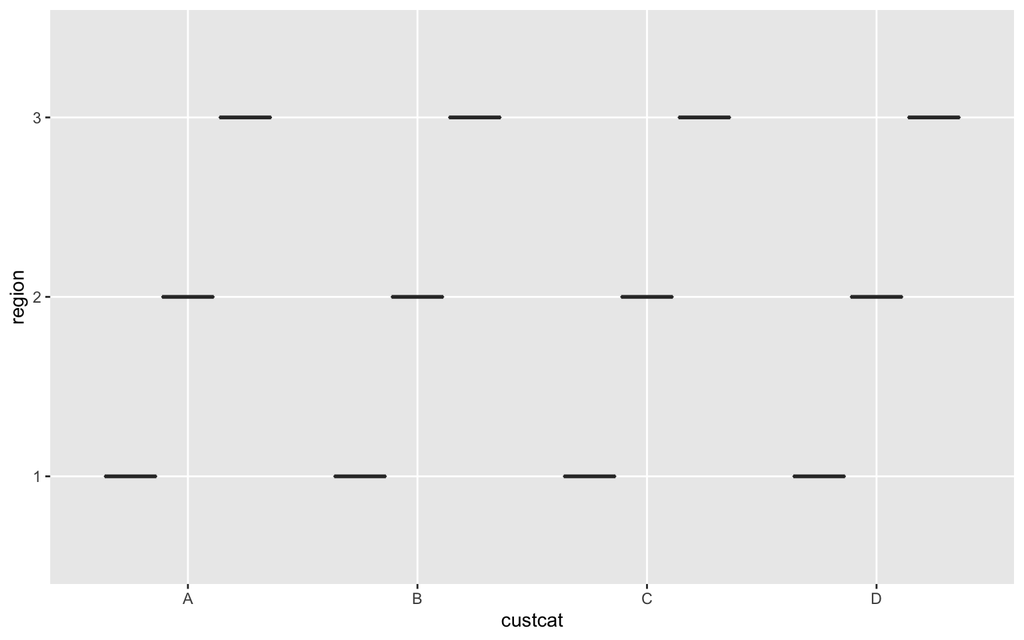

```r
tele %>%
  ggplot(aes(x=custcat, y= region)) + geom_boxplot()
```

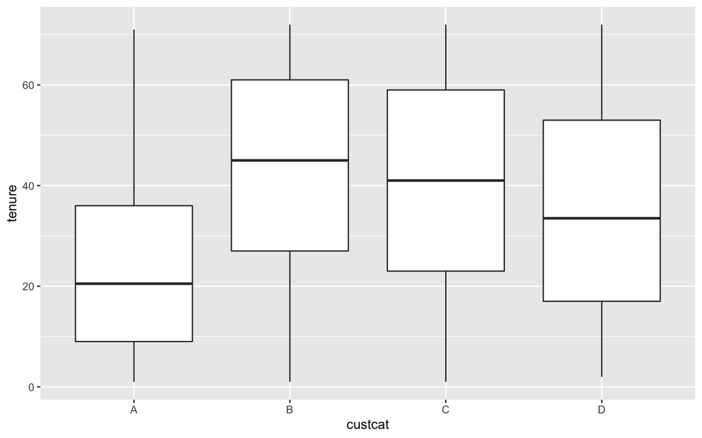

```r
tele %>%
  ggplot(aes(x=custcat, y= tenure)) + geom_boxplot()
```

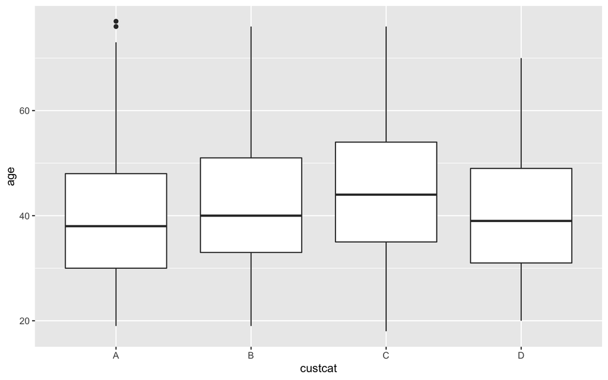

```r
tele %>%
  ggplot(aes(x=custcat, y= age)) + geom_boxplot()
```

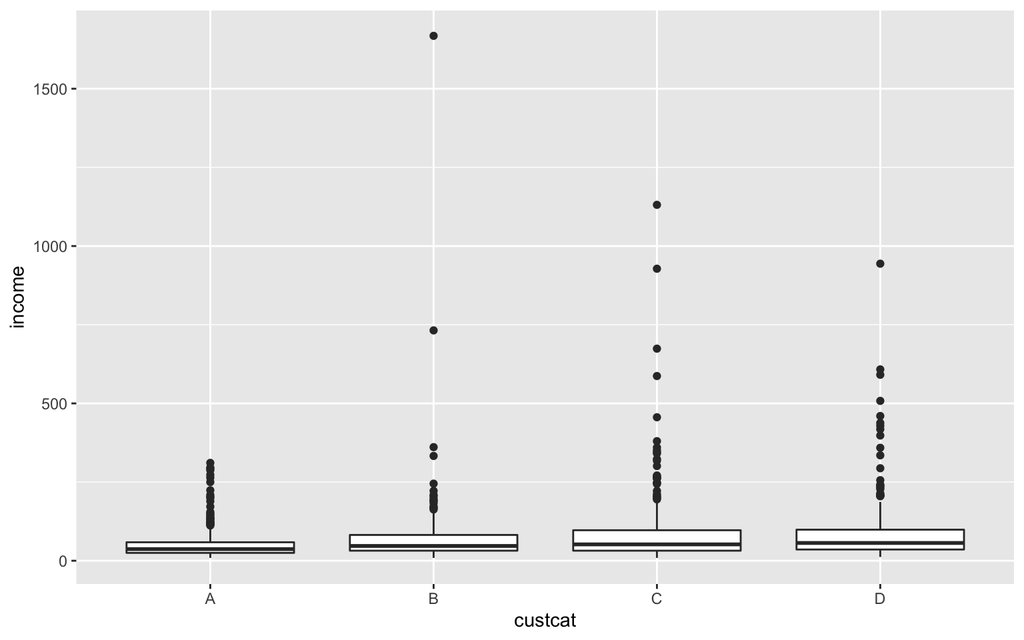

```r
tele %>%
  ggplot(aes(x=custcat, y= income)) + geom_boxplot()
```

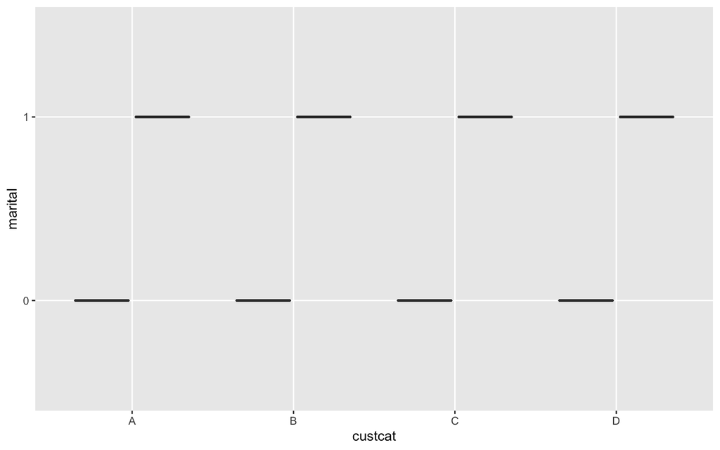

```r
tele %>%
  ggplot(aes(x=custcat, y= marital)) + geom_boxplot()
```

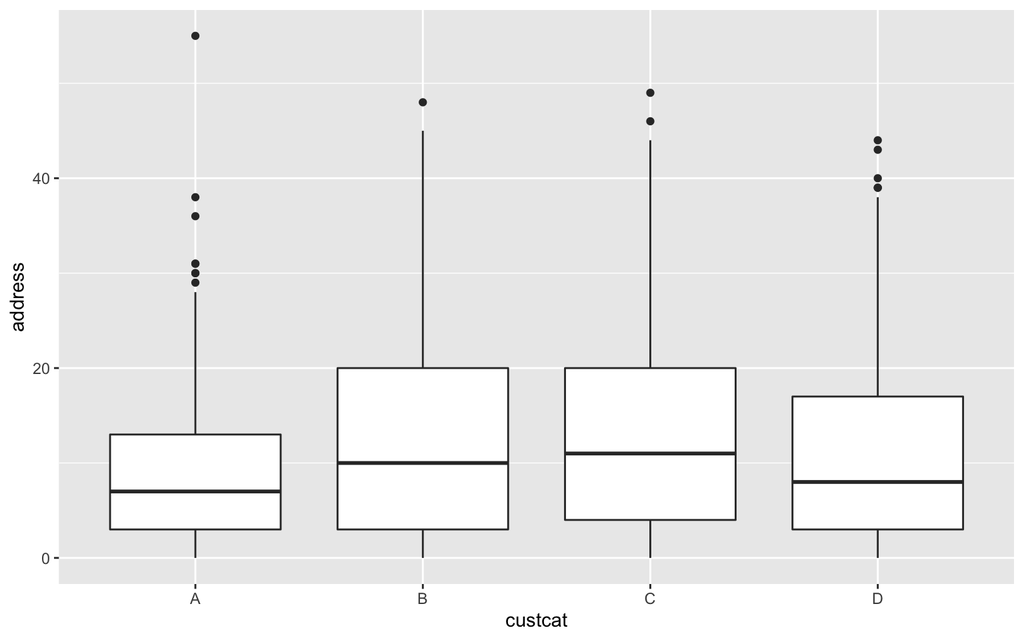

```r
tele %>%
  ggplot(aes(x=custcat, y= address)) + geom_boxplot()
```

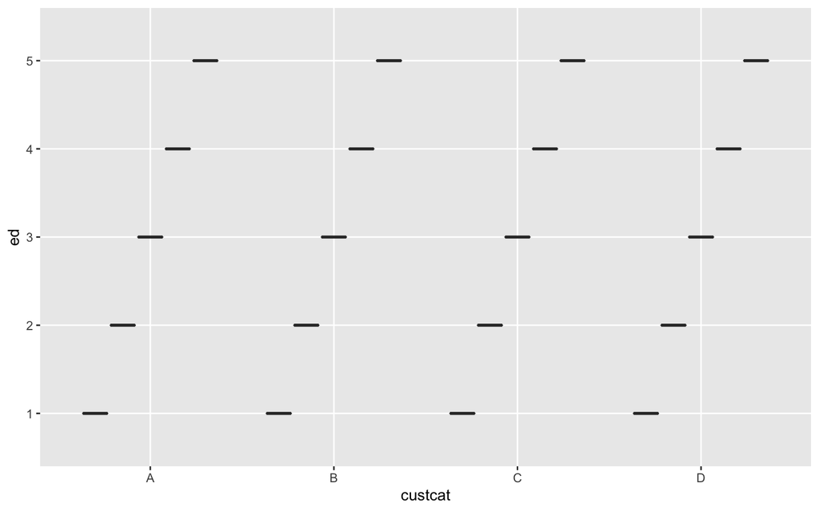

```r
tele %>%
  ggplot(aes(x=custcat, y= ed)) + geom_boxplot()
```

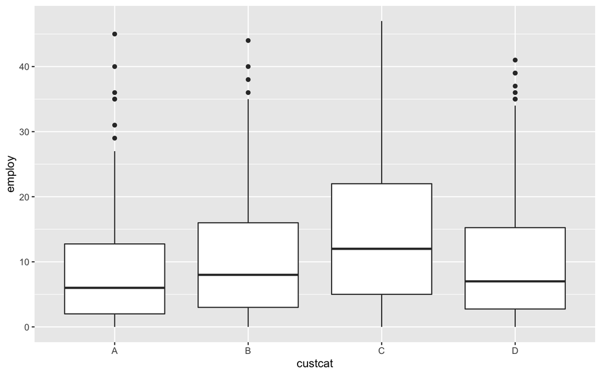

```r
tele %>%
  ggplot(aes(x=custcat, y= employ)) + geom_boxplot()
```

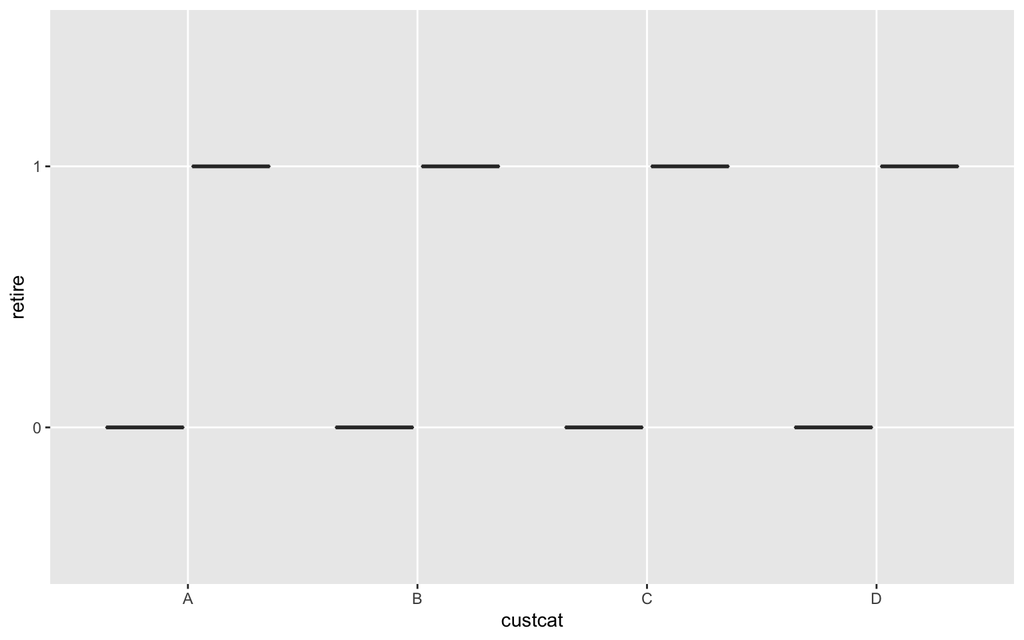

```r
tele %>%
  ggplot(aes(x=custcat, y= retire)) + geom_boxplot()
```

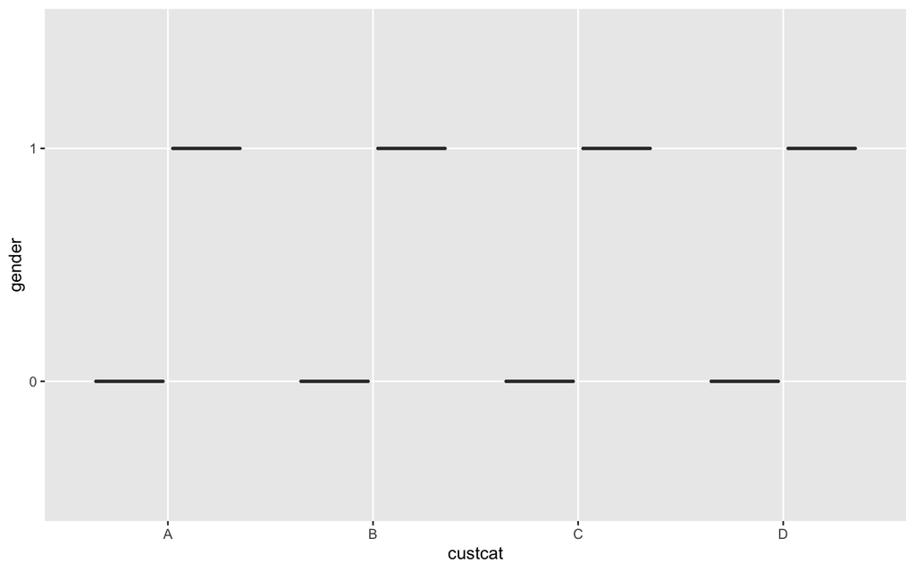

```r
tele %>%
  ggplot(aes(x=custcat, y= gender)) + geom_boxplot()
```

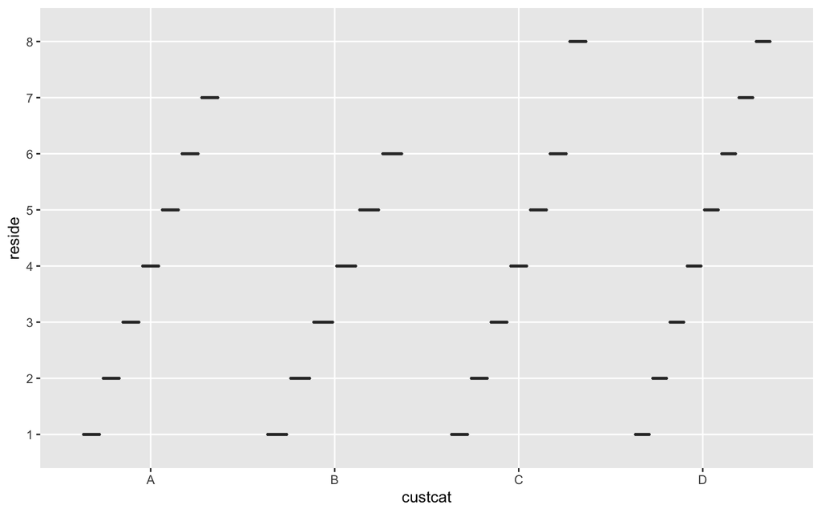

```r
tele %>%
  ggplot(aes(x=custcat, y= reside)) + geom_boxplot()
```

##### Correlation Heatmap

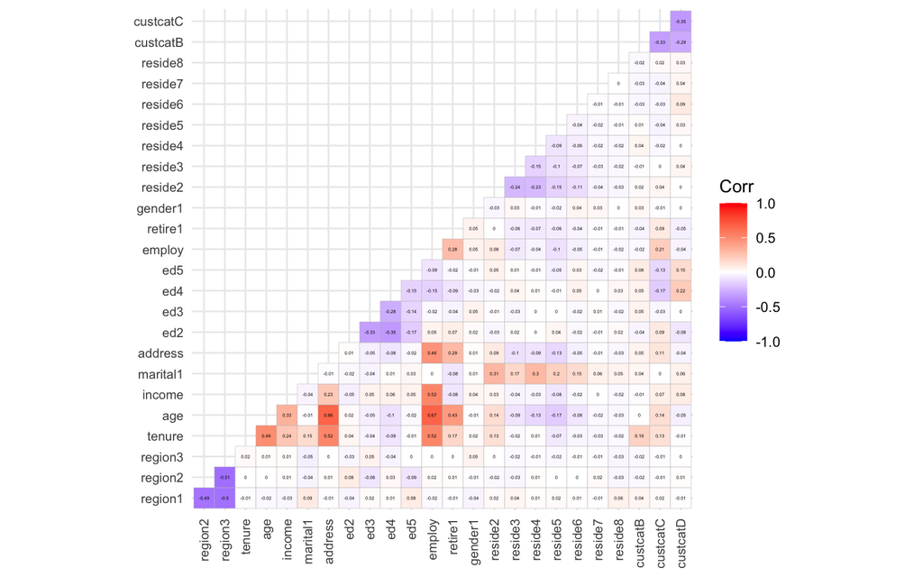

```r
model.matrix(~0+., data=tele) %>%
  cor(use="pairwise.complete.obs") %>%
  ggcorrplot(show.diag = F, type="lower", lab=TRUE, lab_size=1) + theme(axis.text.x = element_text(angle = 90, vjust = 0.5, hjust=1, size = 8)) +
  theme(axis.text.y = element_text(size = 8))
```

You’ve been tasked with studying the customer demographics and customer categories. The company would like two results from you:

1. A model that can be used to predict what category a new customer who signs up will likely fall into.

##### Cross Validation and Recipes

```r
tele_cvs <- vfold_cv(tele, v = 10)

tele_recipe1 <- recipe(custcat ~ .,
                     data = tele) %>%
  step_normalize(all_numeric()) %>%
  step_dummy(all_nominal(), -custcat)

tele_recipe2 <- recipe(custcat ~ tenure + age + income + marital + ed + address + employ + retire +gender,
                     data = tele) %>%
  step_normalize(all_numeric()) %>%
  step_dummy(all_nominal(), -custcat)

tele_recipe3 <- recipe(custcat ~ region + tenure  + income + ed,
                     data = tele) %>%
  step_normalize(all_numeric()) %>%
  step_dummy(all_nominal(), -custcat)
```

##### Random Forests 1

```r
tele_mtry_grid <- grid_regular(mtry(c(1, 10)), levels = 5)

tele_rf_mod <- rand_forest(mtry = tune()) %>%
  set_engine("ranger") %>%
  set_mode("classification")

tele_rf_wflow <- workflow() %>%
  add_model(tele_rf_mod) %>%
  add_recipe(tele_recipe1)

tele_rf_fit <- tele_rf_wflow %>%
  tune_grid(
    grid = tele_mtry_grid,
    resamples = tele_cvs
    )

tele_tuning <- tele_rf_fit %>% collect_metrics()

tele_tuning %>%
  arrange(desc(mean))
```

```
## # A tibble: 10 × 7
##     mtry .metric  .estimator  mean     n std_err .config
##    <int> <chr>    <chr>      <dbl> <int>   <dbl> <chr>
##  1     3 roc_auc  hand_till  0.654    10 0.00620 Preprocessor1_Model2
##  2     5 roc_auc  hand_till  0.652    10 0.00687 Preprocessor1_Model3
##  3     7 roc_auc  hand_till  0.648    10 0.00643 Preprocessor1_Model4
##  4    10 roc_auc  hand_till  0.646    10 0.00737 Preprocessor1_Model5
##  5     1 roc_auc  hand_till  0.642    10 0.00691 Preprocessor1_Model1
##  6     5 accuracy multiclass 0.386    10 0.00718 Preprocessor1_Model3
##  7     1 accuracy multiclass 0.38     10 0.0101  Preprocessor1_Model1
##  8     3 accuracy multiclass 0.377    10 0.00883 Preprocessor1_Model2
##  9     7 accuracy multiclass 0.371    10 0.00795 Preprocessor1_Model4
## 10    10 accuracy multiclass 0.37     10 0.00955 Preprocessor1_Model5
```

##### Random Forests 2

```r
tele_mtry_grid <- grid_regular(mtry(c(1, 10)), levels = 5)

tele_rf_mod <- rand_forest(mtry = tune()) %>%
  set_engine("ranger") %>%
  set_mode("classification")

tele_rf_wflow <- workflow() %>%
  add_model(tele_rf_mod) %>%
  add_recipe(tele_recipe2)

tele_rf_fit <- tele_rf_wflow %>%
  tune_grid(
    grid = tele_mtry_grid,
    resamples = tele_cvs
    )

tele_tuning <- tele_rf_fit %>% collect_metrics()

tele_tuning %>%
  arrange(desc(mean))
```

```
## # A tibble: 10 × 7
##     mtry .metric  .estimator  mean     n std_err .config
##    <int> <chr>    <chr>      <dbl> <int>   <dbl> <chr>
##  1     1 roc_auc  hand_till  0.659    10 0.00693 Preprocessor1_Model1
##  2     3 roc_auc  hand_till  0.655    10 0.00709 Preprocessor1_Model2
##  3     5 roc_auc  hand_till  0.649    10 0.00731 Preprocessor1_Model3
##  4     7 roc_auc  hand_till  0.644    10 0.00735 Preprocessor1_Model4
##  5    10 roc_auc  hand_till  0.639    10 0.00719 Preprocessor1_Model5
##  6     1 accuracy multiclass 0.378    10 0.00854 Preprocessor1_Model1
##  7     7 accuracy multiclass 0.367    10 0.00943 Preprocessor1_Model4
##  8     5 accuracy multiclass 0.363    10 0.0100  Preprocessor1_Model3
##  9     3 accuracy multiclass 0.36     10 0.00715 Preprocessor1_Model2
## 10    10 accuracy multiclass 0.359    10 0.00809 Preprocessor1_Model5
```

##### Random Forests 3

```r
tele_mtry_grid <- grid_regular(mtry(c(1, 10)), levels = 5)

tele_rf_mod <- rand_forest(mtry = tune()) %>%
  set_engine("ranger") %>%
  set_mode("classification")

tele_rf_wflow <- workflow() %>%
  add_model(tele_rf_mod) %>%
  add_recipe(tele_recipe3)

tele_rf_fit <- tele_rf_wflow %>%
  tune_grid(
    grid = tele_mtry_grid,
    resamples = tele_cvs
    )
```

[output not shown]

[output not shown]

[output not shown]

[output not shown]

[output not shown]

[output not shown]

[output not shown]

[output not shown]

[output not shown]

[output not shown]

```r
tele_tuning <- tele_rf_fit %>% collect_metrics()

tele_tuning %>%
  arrange(desc(mean))
```

```
## # A tibble: 10 × 7
##     mtry .metric  .estimator  mean     n std_err .config
##    <int> <chr>    <chr>      <dbl> <int>   <dbl> <chr>
##  1     1 roc_auc  hand_till  0.664    10 0.00887 Preprocessor1_Model1
##  2     3 roc_auc  hand_till  0.662    10 0.00634 Preprocessor1_Model2
##  3     5 roc_auc  hand_till  0.645    10 0.00505 Preprocessor1_Model3
##  4     7 roc_auc  hand_till  0.637    10 0.00579 Preprocessor1_Model4
##  5    10 roc_auc  hand_till  0.636    10 0.00539 Preprocessor1_Model5
##  6     3 accuracy multiclass 0.389    10 0.0129  Preprocessor1_Model2
##  7     1 accuracy multiclass 0.387    10 0.00857 Preprocessor1_Model1
##  8    10 accuracy multiclass 0.369    10 0.0135  Preprocessor1_Model5
##  9     5 accuracy multiclass 0.365    10 0.0144  Preprocessor1_Model3
## 10     7 accuracy multiclass 0.363    10 0.0139  Preprocessor1_Model4
```

- Random Forests were a horrible model for this dataset.

##### Decision Tree 1

```r
tele_tree_grid <- grid_regular(cost_complexity(),
                          tree_depth(),
                          min_n(),
                          levels = 2)

tele_tree_mod <- decision_tree(cost_complexity = tune(),
                          tree_depth = tune(),
                          min_n = tune()) %>%
  set_engine("rpart") %>%
  set_mode("classification")

tele_tree_wflow <- workflow() %>%
  add_recipe(tele_recipe1) %>%
  add_model(tele_tree_mod)

tree_grid_search <-
  tune_grid(
    tele_tree_wflow,
    resamples = tele_cvs,
    grid = tele_tree_grid
  )
tuning_metrics <- tree_grid_search %>% collect_metrics()

tuning_metrics %>%
  arrange(desc(mean))
```

```
## # A tibble: 16 × 9
##    cost_complexity tree_depth min_n .metric  .esti…¹  mean     n std_err .config
##              <dbl>      <int> <int> <chr>    <chr>   <dbl> <int>   <dbl> <chr>
##  1    0.0000000001         15    40 roc_auc  hand_t… 0.640    10 0.00923 Prepro…
##  2    0.0000000001          1     2 roc_auc  hand_t… 0.547    10 0.0133  Prepro…
##  3    0.0000000001          1    40 roc_auc  hand_t… 0.547    10 0.0133  Prepro…
##  4    0.1                   1     2 roc_auc  hand_t… 0.537    10 0.0146  Prepro…
##  5    0.1                  15     2 roc_auc  hand_t… 0.537    10 0.0146  Prepro…
##  6    0.1                   1    40 roc_auc  hand_t… 0.537    10 0.0146  Prepro…
##  7    0.1                  15    40 roc_auc  hand_t… 0.537    10 0.0146  Prepro…
##  8    0.0000000001         15     2 roc_auc  hand_t… 0.521    10 0.00982 Prepro…
##  9    0.0000000001         15    40 accuracy multic… 0.389    10 0.0133  Prepro…
## 10    0.0000000001          1     2 accuracy multic… 0.333    10 0.0158  Prepro…
## 11    0.0000000001          1    40 accuracy multic… 0.333    10 0.0158  Prepro…
## 12    0.1                   1     2 accuracy multic… 0.32     10 0.0209  Prepro…
## 13    0.1                  15     2 accuracy multic… 0.32     10 0.0209  Prepro…
## 14    0.1                   1    40 accuracy multic… 0.32     10 0.0209  Prepro…
## 15    0.1                  15    40 accuracy multic… 0.32     10 0.0209  Prepro…
## 16    0.0000000001         15     2 accuracy multic… 0.289    10 0.0153  Prepro…
## # … with abbreviated variable name ¹.estimator
```

##### Decision Tree 2

```r
tele_tree_grid <- grid_regular(cost_complexity(),
                          tree_depth(),
                          min_n(),
                          levels = 2)

tele_tree_mod <- decision_tree(cost_complexity = tune(),
                          tree_depth = tune(),
                          min_n = tune()) %>%
  set_engine("rpart") %>%
  set_mode("classification")

tele_tree_wflow <- workflow() %>%
  add_recipe(tele_recipe2) %>%
  add_model(tele_tree_mod)

tree_grid_search <-
  tune_grid(
    tele_tree_wflow,
    resamples = tele_cvs,
    grid = tele_tree_grid
  )
tuning_metrics <- tree_grid_search %>% collect_metrics()

tuning_metrics %>%
  arrange(desc(mean))
```

```
## # A tibble: 16 × 9
##    cost_complexity tree_depth min_n .metric  .esti…¹  mean     n std_err .config
##              <dbl>      <int> <int> <chr>    <chr>   <dbl> <int>   <dbl> <chr>
##  1    0.0000000001         15    40 roc_auc  hand_t… 0.646    10 0.00975 Prepro…
##  2    0.0000000001          1     2 roc_auc  hand_t… 0.547    10 0.0133  Prepro…
##  3    0.0000000001          1    40 roc_auc  hand_t… 0.547    10 0.0133  Prepro…
##  4    0.1                   1     2 roc_auc  hand_t… 0.537    10 0.0146  Prepro…
##  5    0.1                  15     2 roc_auc  hand_t… 0.537    10 0.0146  Prepro…
##  6    0.1                   1    40 roc_auc  hand_t… 0.537    10 0.0146  Prepro…
##  7    0.1                  15    40 roc_auc  hand_t… 0.537    10 0.0146  Prepro…
##  8    0.0000000001         15     2 roc_auc  hand_t… 0.537    10 0.00734 Prepro…
##  9    0.0000000001         15    40 accuracy multic… 0.396    10 0.0133  Prepro…
## 10    0.0000000001          1     2 accuracy multic… 0.333    10 0.0158  Prepro…
## 11    0.0000000001          1    40 accuracy multic… 0.333    10 0.0158  Prepro…
## 12    0.1                   1     2 accuracy multic… 0.32     10 0.0209  Prepro…
## 13    0.1                  15     2 accuracy multic… 0.32     10 0.0209  Prepro…
## 14    0.1                   1    40 accuracy multic… 0.32     10 0.0209  Prepro…
## 15    0.1                  15    40 accuracy multic… 0.32     10 0.0209  Prepro…
## 16    0.0000000001         15     2 accuracy multic… 0.308    10 0.0108  Prepro…
## # … with abbreviated variable name ¹.estimator
```

##### Decision Tree 3

```r
tele_tree_grid <- grid_regular(cost_complexity(),
                          tree_depth(),
                          min_n(),
                          levels = 2)

tele_tree_mod <- decision_tree(cost_complexity = tune(),
                          tree_depth = tune(),
                          min_n = tune()) %>%
  set_engine("rpart") %>%
  set_mode("classification")

tele_tree_wflow <- workflow() %>%
  add_recipe(tele_recipe3) %>%
  add_model(tele_tree_mod)

tree_grid_search <-
  tune_grid(
    tele_tree_wflow,
    resamples = tele_cvs,
    grid = tele_tree_grid
  )
tuning_metrics <- tree_grid_search %>% collect_metrics()

tuning_metrics %>%
  arrange(desc(mean))
```

```
## # A tibble: 16 × 9
##    cost_complexity tree_depth min_n .metric  .esti…¹  mean     n std_err .config
##              <dbl>      <int> <int> <chr>    <chr>   <dbl> <int>   <dbl> <chr>
##  1    0.0000000001         15    40 roc_auc  hand_t… 0.641    10  0.0108 Prepro…
##  2    0.0000000001          1     2 roc_auc  hand_t… 0.547    10  0.0133 Prepro…
##  3    0.0000000001          1    40 roc_auc  hand_t… 0.547    10  0.0133 Prepro…
##  4    0.0000000001         15     2 roc_auc  hand_t… 0.540    10  0.0110 Prepro…
##  5    0.1                   1     2 roc_auc  hand_t… 0.537    10  0.0146 Prepro…
##  6    0.1                  15     2 roc_auc  hand_t… 0.537    10  0.0146 Prepro…
##  7    0.1                   1    40 roc_auc  hand_t… 0.537    10  0.0146 Prepro…
##  8    0.1                  15    40 roc_auc  hand_t… 0.537    10  0.0146 Prepro…
##  9    0.0000000001         15    40 accuracy multic… 0.358    10  0.0122 Prepro…
## 10    0.0000000001          1     2 accuracy multic… 0.333    10  0.0158 Prepro…
## 11    0.0000000001          1    40 accuracy multic… 0.333    10  0.0158 Prepro…
## 12    0.1                   1     2 accuracy multic… 0.32     10  0.0209 Prepro…
## 13    0.1                  15     2 accuracy multic… 0.32     10  0.0209 Prepro…
## 14    0.1                   1    40 accuracy multic… 0.32     10  0.0209 Prepro…
## 15    0.1                  15    40 accuracy multic… 0.32     10  0.0209 Prepro…
## 16    0.0000000001         15     2 accuracy multic… 0.312    10  0.0161 Prepro…
## # … with abbreviated variable name ¹.estimator
```

-Decision trees were worse than random forests and also a horrible model for this dataset.

##### KNN1

```r
knn_spec <- nearest_neighbor(neighbors = tune()) %>%
  set_engine("kknn") %>%
  set_mode("classification")

k_grid <- grid_regular(neighbors(c(2, 40)), levels = 10)
set.seed(10)

knn_wflow <- workflow() %>%
  add_model(knn_spec) %>%
  add_recipe(tele_recipe1)

knn_wflow %>%
  tune_grid(
    grid = k_grid,
    resamples = tele_cvs
  ) %>%
  collect_metrics() %>%
  filter(.metric == "accuracy") %>%
  arrange(desc(mean))
```

```
## # A tibble: 10 × 7
##    neighbors .metric  .estimator  mean     n std_err .config
##        <int> <chr>    <chr>      <dbl> <int>   <dbl> <chr>
##  1        40 accuracy multiclass 0.342    10  0.0108 Preprocessor1_Model10
##  2        35 accuracy multiclass 0.338    10  0.0111 Preprocessor1_Model09
##  3        27 accuracy multiclass 0.335    10  0.0128 Preprocessor1_Model07
##  4        31 accuracy multiclass 0.334    10  0.0113 Preprocessor1_Model08
##  5        23 accuracy multiclass 0.333    10  0.0111 Preprocessor1_Model06
##  6        18 accuracy multiclass 0.325    10  0.0118 Preprocessor1_Model05
##  7        14 accuracy multiclass 0.322    10  0.0130 Preprocessor1_Model04
##  8        10 accuracy multiclass 0.306    10  0.0163 Preprocessor1_Model03
##  9         6 accuracy multiclass 0.298    10  0.0134 Preprocessor1_Model02
## 10         2 accuracy multiclass 0.284    10  0.0139 Preprocessor1_Model01
```

##### KNN2

```r
knn_spec <- nearest_neighbor(neighbors = tune()) %>%
  set_engine("kknn") %>%
  set_mode("classification")

k_grid <- grid_regular(neighbors(c(2, 40)), levels = 10)
set.seed(10)

knn_wflow <- workflow() %>%
  add_model(knn_spec) %>%
  add_recipe(tele_recipe2)

knn_wflow %>%
  tune_grid(
    grid = k_grid,
    resamples = tele_cvs
  ) %>%
  collect_metrics() %>%
  filter(.metric == "accuracy") %>%
  arrange(desc(mean))
```

```
## # A tibble: 10 × 7
##    neighbors .metric  .estimator  mean     n std_err .config
##        <int> <chr>    <chr>      <dbl> <int>   <dbl> <chr>
##  1        23 accuracy multiclass 0.354    10  0.0126 Preprocessor1_Model06
##  2        27 accuracy multiclass 0.351    10  0.0104 Preprocessor1_Model07
##  3        18 accuracy multiclass 0.349    10  0.0164 Preprocessor1_Model05
##  4        40 accuracy multiclass 0.349    10  0.009  Preprocessor1_Model10
##  5        35 accuracy multiclass 0.347    10  0.0101 Preprocessor1_Model09
##  6        14 accuracy multiclass 0.344    10  0.0142 Preprocessor1_Model04
##  7        10 accuracy multiclass 0.343    10  0.0141 Preprocessor1_Model03
##  8        31 accuracy multiclass 0.343    10  0.0107 Preprocessor1_Model08
##  9         6 accuracy multiclass 0.325    10  0.0114 Preprocessor1_Model02
## 10         2 accuracy multiclass 0.322    10  0.0118 Preprocessor1_Model01
```

##### KNN3

```r
knn_spec <- nearest_neighbor(neighbors = tune()) %>%
  set_engine("kknn") %>%
  set_mode("classification")

k_grid <- grid_regular(neighbors(c(2, 40)), levels = 10)
set.seed(10)

knn_wflow <- workflow() %>%
  add_model(knn_spec) %>%
  add_recipe(tele_recipe3)

knn_wflow %>%
  tune_grid(
    grid = k_grid,
    resamples = tele_cvs
  ) %>%
  collect_metrics() %>%
  filter(.metric == "accuracy") %>%
  arrange(desc(mean))
```

```
## # A tibble: 10 × 7
##    neighbors .metric  .estimator  mean     n std_err .config
##        <int> <chr>    <chr>      <dbl> <int>   <dbl> <chr>
##  1        40 accuracy multiclass 0.365    10 0.0115  Preprocessor1_Model10
##  2        35 accuracy multiclass 0.359    10 0.0126  Preprocessor1_Model09
##  3        27 accuracy multiclass 0.357    10 0.0110  Preprocessor1_Model07
##  4        31 accuracy multiclass 0.355    10 0.0109  Preprocessor1_Model08
##  5        23 accuracy multiclass 0.352    10 0.0105  Preprocessor1_Model06
##  6        18 accuracy multiclass 0.349    10 0.0120  Preprocessor1_Model05
##  7        14 accuracy multiclass 0.343    10 0.0103  Preprocessor1_Model04
##  8        10 accuracy multiclass 0.342    10 0.0158  Preprocessor1_Model03
##  9         6 accuracy multiclass 0.321    10 0.0142  Preprocessor1_Model02
## 10         2 accuracy multiclass 0.311    10 0.00960 Preprocessor1_Model01
```

- KNN was just as if not worse than the previous models.
2. Insight into what demographics are associated with these customer differences.

```r
tree_grid <- grid_regular(cost_complexity(),
                          tree_depth(),
                          min_n(),
                          levels = 2)

tele_recipe2x <- recipe(custcat ~ .,
                     data = tele, importance = TRUE)
```

```r
tele_rf_mod <- rand_forest(
  mtry = tune(),
  trees = tune(),
  min_n = tune()
) %>%
  set_engine("ranger") %>%
  set_mode("classification")

tele_rf_wflow <- workflow() %>%
  add_recipe(tele_recipe2x) %>%
  add_model(tele_rf_mod)

grid_search <-
  tune_grid(
    tele_rf_wflow,
    resamples = tele_cvs,
    grid = 25,
    control = control_grid(save_pred = TRUE)
  )
```

```
## i Creating pre-processing data to finalize unknown parameter: mtry
```

```r
tuning_metrics <- grid_search %>% collect_metrics

tuning_metrics %>%
  arrange(desc(mean))
```

```
## # A tibble: 50 × 9
##     mtry trees min_n .metric .estimator  mean     n std_err .config
##    <int> <int> <int> <chr>   <chr>      <dbl> <int>   <dbl> <chr>
##  1     8   807    32 roc_auc hand_till  0.677    10 0.00785 Preprocessor1_Model…
##  2     4  1744    30 roc_auc hand_till  0.677    10 0.00738 Preprocessor1_Model…
##  3     9   237    38 roc_auc hand_till  0.676    10 0.00919 Preprocessor1_Model…
##  4    11   562    39 roc_auc hand_till  0.676    10 0.00768 Preprocessor1_Model…
##  5    10   298    35 roc_auc hand_till  0.676    10 0.00717 Preprocessor1_Model…
##  6     6   999    28 roc_auc hand_till  0.675    10 0.00771 Preprocessor1_Model…
##  7     2  1520    23 roc_auc hand_till  0.675    10 0.00815 Preprocessor1_Model…
##  8     7    89    27 roc_auc hand_till  0.674    10 0.00924 Preprocessor1_Model…
##  9     6  1140    26 roc_auc hand_till  0.674    10 0.00769 Preprocessor1_Model…
## 10     4  1066    23 roc_auc hand_till  0.674    10 0.00763 Preprocessor1_Model…
## # … with 40 more rows
## # ℹ Use `print(n = ...)` to see more rows
```

```r
splits <- initial_split(tele)

last_rf_mod <-
  rand_forest(mtry = 8, min_n = 39, trees = 871 ) %>%
  set_engine("ranger", importance = "impurity") %>%
  set_mode("classification")

# the last workflow
last_rf_workflow <-
  tele_rf_wflow %>%
  update_model(last_rf_mod)

# the last fit
set.seed(345)
last_rf_fit <-
  last_rf_workflow %>%
  last_fit(splits)

last_rf_fit
```

```
## # Resampling results
## # Manual resampling
## # A tibble: 1 × 6
##   splits            id               .metrics .notes   .predictions .workflow
##   <list>            <chr>            <list>   <list>   <list>       <list>
## 1 <split [750/250]> train/test split <tibble> <tibble> <tibble>     <workflow>
```

```r
last_rf_fit %>%
  collect_metrics()
```

```
## # A tibble: 2 × 4
##   .metric  .estimator .estimate .config
##   <chr>    <chr>          <dbl> <chr>
## 1 accuracy multiclass     0.348 Preprocessor1_Model1
## 2 roc_auc  hand_till      0.649 Preprocessor1_Model1
```

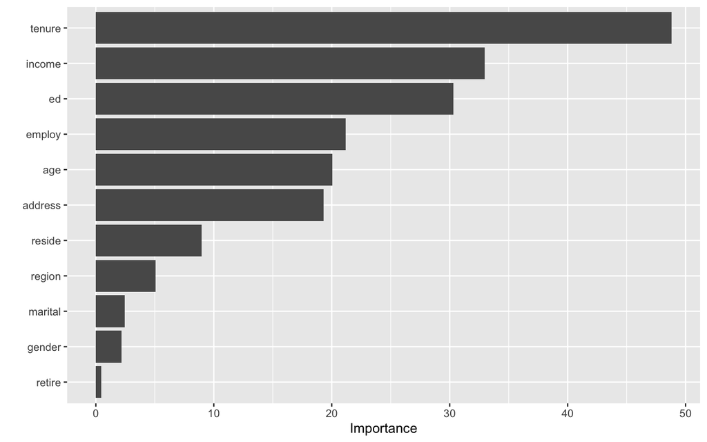

```r
last_rf_fit %>%
  extract_fit_parsnip() %>%
  vip(num_features = 11)
```

### Part Four: Report to your manager

Your manager, the head of the Data Science department, would like a summary of your work.

She does not need to see every single detail of every step of your process, but she does need to know a basic outline of what you tried, how you made your decisions, and why you settled on certain choices.

You should share only as much of your code and results as you feel is necessary for her to get the “big picture” of your approach. You can assume she has taken our course, and you may use any “lingo” you want; for example, you can reference the Gini Index without having to explain what it is.

- In order to understand how customer demographics impact consumer behavior the first step was to load and clean the data.

```r
tele <- read_csv("https://www.dropbox.com/s/9dymy30v394ud8h/Telecust1.csv?dl=1")
```

Cleaning the data just meant converting certain variables to factors.

```r
tele <- tele %>%
  mutate(region = as.factor(region),
         marital = as.factor(marital),
         ed = as.factor(ed),
         retire = as.factor(retire),
         gender = as.factor(gender),
         reside = as.factor(reside),
         custcat = as.factor(custcat))
```

Next, I wanted to explore the dataset further, so I plotted all the predictor variables against consumer behavior (custcat) in the form of box plots. One example of this process is as follows.

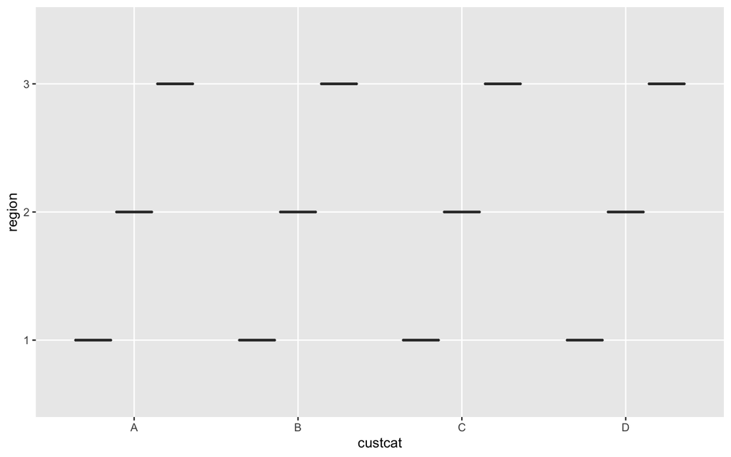

```r
tele %>%
  ggplot(aes(x=custcat, y= region)) + geom_boxplot()
```

Furthermore, I also produced a heatmap showing correlation between variables.

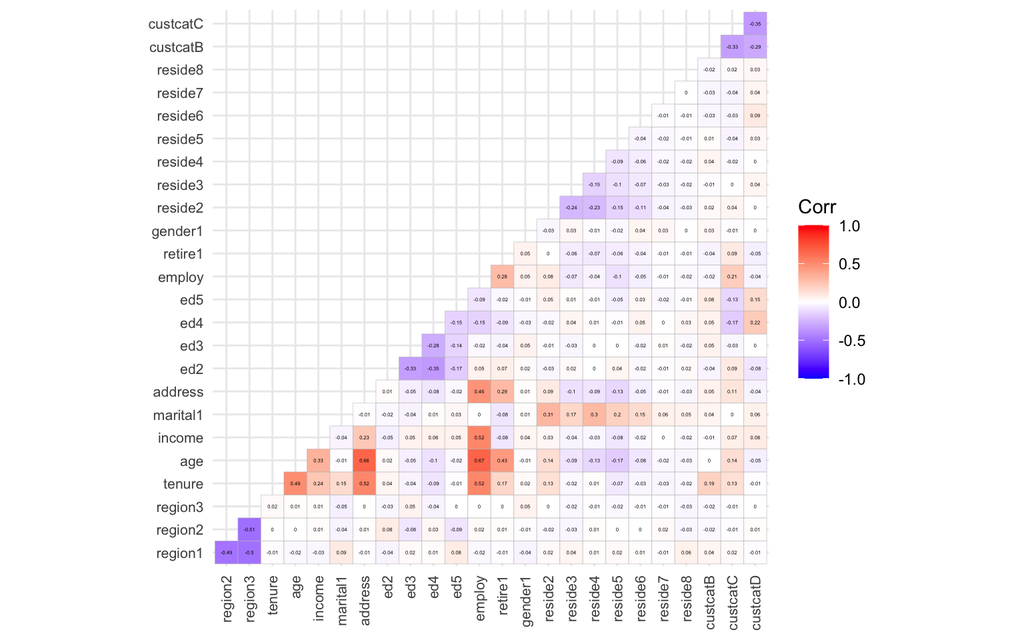

```r
model.matrix(~0+., data=tele) %>%
  cor(use="pairwise.complete.obs") %>%
  ggcorrplot(show.diag = F, type="lower", lab=TRUE, lab_size=1) + theme(axis.text.x = element_text(angle = 90, vjust = 0.5, hjust=1, size = 8)) +
  theme(axis.text.y = element_text(size = 8))
```

All this was done, in order to develop strong recipes of success as we now know better how and which predictor variables impacted consumer behavior best. After conducting a short exploratory data analysis, a cross validation sample was set up to fit on future models.

```r
tele_cvs <- vfold_cv(tele, v = 10)
```

Next, using the EDA, 3 recipes were created. All the recipes were normalized and dummified. Starting with all the predictor variables in the dataset in recipe 1, I narrowed down the predictor variables in recipe 2 and 3 using information from the EDA to select the most important predictor variables.

```r
tele_recipe1 <- recipe(custcat ~ .,
                     data = tele) %>%
  step_normalize(all_numeric()) %>%
  step_dummy(all_nominal(), -custcat)

tele_recipe2 <- recipe(custcat ~ tenure + age + income + marital + ed + address + employ + retire +gender,
                     data = tele) %>%
  step_normalize(all_numeric()) %>%
  step_dummy(all_nominal(), -custcat)

tele_recipe3 <- recipe(custcat ~ region + tenure  + income + ed,
                     data = tele) %>%
  step_normalize(all_numeric()) %>%
  step_dummy(all_nominal(), -custcat)
```

```r
tele_mtry_grid <- grid_regular(mtry(c(1, 10)), levels = 5)

tele_rf_mod <- rand_forest(mtry = tune()) %>%
  set_engine("ranger") %>%
  set_mode("classification")

tele_rf_wflow <- workflow() %>%
  add_model(tele_rf_mod) %>%
  add_recipe(tele_recipe2)

tele_rf_fit <- tele_rf_wflow %>%
  tune_grid(
    grid = tele_mtry_grid,
    resamples = tele_cvs
    )

tele_tuning <- tele_rf_fit %>% collect_metrics()

tele_tuning %>%
  arrange(desc(mean))
```

```
## # A tibble: 10 × 7
##     mtry .metric  .estimator  mean     n std_err .config
##    <int> <chr>    <chr>      <dbl> <int>   <dbl> <chr>
##  1     1 roc_auc  hand_till  0.656    10 0.00807 Preprocessor1_Model1
##  2     3 roc_auc  hand_till  0.647    10 0.00875 Preprocessor1_Model2
##  3     5 roc_auc  hand_till  0.635    10 0.0108  Preprocessor1_Model3
##  4     7 roc_auc  hand_till  0.631    10 0.00962 Preprocessor1_Model4
##  5    10 roc_auc  hand_till  0.628    10 0.0108  Preprocessor1_Model5
##  6     1 accuracy multiclass 0.372    10 0.0142  Preprocessor1_Model1
##  7     3 accuracy multiclass 0.361    10 0.0115  Preprocessor1_Model2
##  8     5 accuracy multiclass 0.358    10 0.00940 Preprocessor1_Model3
##  9    10 accuracy multiclass 0.35     10 0.0103  Preprocessor1_Model5
## 10     7 accuracy multiclass 0.348    10 0.00867 Preprocessor1_Model4
```

Next, I wanted to get better insights on how the demographics are associated with customer differences. To do so, I created VIP plot using random forests. Since, I wanted to look at all the demographics/predictor variables, I changed the recipe accordingly to create the chart.

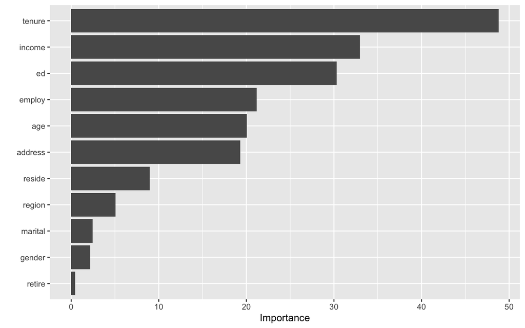

```r
last_rf_fit %>%
  extract_fit_parsnip() %>%
  vip(num_features = 11)
```

As one can see from the results, tenure, income and educations seem to be the most important demographics impacting customer differences.